# Résumé

# 6 Effet moyen du traitement sur les traités et le contrôle

Pour évaluer les implications politiques d’une intervention particulière, nous avons souvent besoin de connaître l’effet du traitement non seulement sur l’ensemble de la population mais spécifiquement pour ceux à qui le traitement est administré. Nous définissons l’effet moyen du traitement pour les traitées (ATT) et le contrôle (ATC) comme de simples comparaisons contrefactuelles :

$$ATT=E(Y_i(1)-Y_i(0)|D_i=1)=E(Y_i(1)|D_i=1)-E(Y_i(0)|D_i=1)$$
$$ATC=E(Y_i(1)-Y_i(0)|D_i=0)=E(Y_i(1)|D_i=0)-E(Y_i(0)|D_i=0)$$

Simplement, l’ATT est l’effet pour ceux que nous avons traités ; l’ATC est ce que l’effet *serait* pour ceux que nous n’avons pas traités.

Lorsque le traitement est assigné de manière aléatoire et que la conformité est totale, $ATE=ATT=ATC$, puisque $E(Y_i(0)∣D_i=1)=E(Y_i(0)∣D_i=0)$ et $E( Y_i(1)∣D_i=0)=E(Y_i(1)∣D_i=1)$. Souvent, en raison de la nature de l’intervention ou de préoccupations ethniques ou spécifiques au coût, la conformité du traitement est incomplète et l’ATE ne sera pas en général égal à l’ATT ou l’ATC. Dans de tels cas, nous avons vu dans la section précédente que nous pouvions repondérer les observations par leur probabilité de recevoir le traitement pour récupérer les estimations de l’ATE. La même logique peut être étendue pour produire des estimations de l’ATT et de l’ATC dans notre échantillon et dans la population.[^15]

Ci-dessous, nous créons une étude de cas où la probabilité de recevoir un traitement varie mais peut être estimée à l’aide d’un modèle de score de propension.[^16] Les probabilités prédites à partir de ce modèle sont ensuite utilisées comme pondérations pour récupérer les estimations de l’ATE, de l’ATT et de l’ATC. Une pondération inverse du score de propension tente d’équilibrer la distribution des covariables entre les groupes de traitement et de contrôle lors de l’estimation de l’ATE. Pour l’ATT, cette approche de pondération traite les sujets du groupe traité comme un échantillon de la population cible (personnes ayant reçu le traitement) et pondère les sujets du groupe de contrôle en fonction de leur probabilité de recevoir le traitement. De la même manière, l’estimation de l’ATC pondère les observations pour les traités pour qu’elles ressemblent au contrôle. La qualité (l’absence de biais) de ces estimations est intrinsèquement liée à la qualité de nos modèles pour prédire la réception du traitement. La pondération inverse du score de propension et d’autres procédures produisent un équilibre entre les groupes de traitement et de contrôle sur les covariables observées. Mais à moins d’avoir le “vrai modèle” (et nous ne connaissons presque jamais le vrai modèle), le potentiel biais des covariables non observées demeure et devrait nous conduire à interpréter notre ATT ou ATC estimé à la lumière de la qualité du modèle qui l’a produit.

```r
set.seed(1234) # pour la reproductibilité
n = 1000 # taille de la population
X1 = rnorm(n) # covariables de pré-traitement
X2 = rnorm(n)
p = pnorm(-0.5 + 0.75*X2) # probabilité de traitement inégale
D = rbinom(n, 1, p) # traitement
Y0 = rnorm(n) # résultats potentiels
Y1 = Y0 +1 +X1 +X2
Y = D*Y1 + (1-D)*Y0 # résultats observés
samp = data.frame(X1,X2,D,Y)
# modèle du score de propension
samp$p.score<-
predict(glm(D~X1+X2,samp,family=binomial),type="response")
# pondération inverse du score de propension
samp$W.ipw<-with(samp, ifelse(D==1,1/p.score,1/(1-p.score)))
samp$W.att<-with(samp, ifelse(D==1,1,p.score/(1-p.score)))
samp$W.atc<-with(samp, ifelse(D==1,(1-p.score)/p.score,1))
# IPW: ATE, ATT, ATC
ATE.ipw<-coef(lm(Y~D,data=samp,weights=W.ipw))[2]
ATT.ipw<-coef(lm(Y~D,data=samp,weights=W.att))[2]
ATC.ipw<-coef(lm(Y~D,data=samp,weights=W.atc))[2]
```

# 7 Effet moyen du traitement par quantile

L’ATE se concentre sur le milieu, en quelque sorte sur l’effet pour une personne typique, mais nous nous soucions souvent aussi des conséquences distributives de notre traitement. Nous voulons savoir non seulement si notre traitement a augmenté le revenu moyen, mais aussi s’il a rendu la distribution des revenus dans l’étude plus ou moins égale.

Les affirmations concernant les distributions sont difficiles. Même si nous pouvons estimer l’ATE à partir d’une différence des moyennes d’échantillon, en général, nous ne pouvons pas faire de déclarations sur la distribution conjointe des résultats potentiels $F(Yi(1),Yi(0))$ sans hypothèse supplémentaire. En règle générale, ces hypothèses limitent notre analyse à une sous-population spécifique[^17] ou nous obligent à supposer une certaine forme d’invariance de rang dans la distribution des réponses à l’effet du traitement[^18]. Voir Frölich et Melly (2010) pour une discussion assez concise sur ces questions. Voir Abbring et Heckman (Abbring, Jaap H et James J Heckman. 2007. “Econometric Evaluation of Social Programs, Part III : Distributional Treatment Effects, Dynamic Treatment Effects, Dynamic Discrete Choice, and General Equilibrium Policy Evaluation”. Handbook of Econometrics 6. Elsevier: 5145-5303.) pour un aperçu complet.

Si ces hypothèses sont justifiées pour nos données, nous pouvons obtenir des estimations cohérentes de l’effet du traitement par quantile (quantile treatment effect, QTE) en utilisant la régression par quantile.[^19] Tout comme la régression linéaire estime l’ATE comme une différence des moyennes (ou, lorsque des covariables sont utilisées dans le modèle, à partir d’une moyenne conditionnelle), la régression par quantile ajuste un modèle linéaire à un quantile conditionnel et ce modèle peut ensuite être utilisé pour estimer l’effet du traitement pour ce quantile particulier du résultat. L’approche peut être étendue pour inclure des covariables et des instruments de non-conformité. Notez que l’interprétation du QTE est pour un quantile donné, non pas pour un individu de ce quantile.

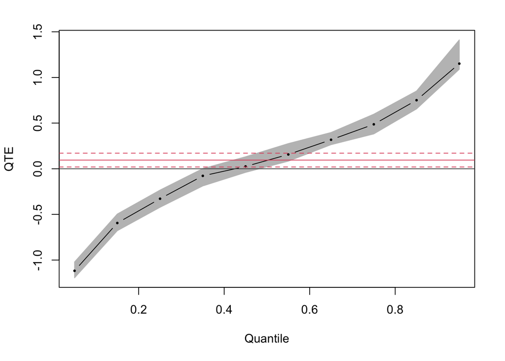

```r
set.seed(1234) # pour la reproductibilité
n = 1000 # taille de la population
Y0 = runif(n) # Résultat potentiel sous la condition de contrôle
Y1= Y0
Y1[Y0 <.5] = Y0[Y0 <.5]-rnorm(length(Y0[Y0 <.5]))
Y1[Y0 >.5] = Y0[Y0 >.5]+rnorm(length(Y0[Y0 >.5]))
D = sample((1:n)%%2) # Traitement: 1 si traité, 0 sinon
Y = D*Y1 + (1-D)*Y0 # Résultat dans la population
samp = data.frame(D,Y)
library(quantreg)
ATE = coef(lm(Y~D,data=samp))[2]
QTE = rq(Y~D,tau =
seq(.05,.95,length.out=10),data=samp,method = "fn")
plot(summary(QTE),parm=2,main="",ylab="QTE",xlab="Quantile",mar = c(5.1, 4.1, 2.1, 2.1))
```

# 8 Effet de médiation

Parfois, nous voulons décrire non seulement l’ampleur et le niveau de signification d’un effet causal observé, mais aussi le mécanisme (ou les mécanismes) qui l’ont produit. Notre intervention a-t-elle augmenté la participation dans le groupe de traitement, en partie, en augmentant le sentiment d’utilité politique pour ces sujets ? Si oui, quelle part de cet effet total peut être attribuée aux effets de médiation de notre traitement sur le sentiment d’utilité ; et de ce sentiment d’utilité sur la participation au vote ?

Baron et Kenny (1986) proposent un cadre général de réflexion sur la médiation en décomposant l’effet total du traitement en son effet indirect sur un médiateur qui affecte ensuite le résultat, appelé effet causal moyen de médiation (average causal mediation effect, ACME), et l’effet moyen direct du traitement (average direct effect, ADE). L’estimation non biaisée de ces effets, cependant, nécessite un ensemble d’hypothèses fortes sur la relation entre le traitement, les médiateurs, les résultats et les facteurs de confusion potentiels, collectivement appelés ignorabilité séquentielle (Imai, Keele et Yamamoto (2010), Bullock, Green et Ha (2010 )).[^20]

La plupart des effets causaux opèrent probablement à travers plusieurs canaux, et donc une hypothèse d’ignorabilité séquentielle pour votre expérience peut être difficile à justifier. Par exemple, la ligne du haut de la figure ci-dessous illustre des situations dans lesquelles l’ignorabilité séquentielle est valable, tandis que la ligne du bas décrit deux cas (parmi de nombreux possibles) dans lesquels l’ignorabilité séquentielle est violée et l’analyse de médiation est biaisée. En essence, la spécification des effets d’un médiateur particulier nécessite des hypothèses fortes sur le rôle de tous les autres médiateurs dans la chaîne causale. Alors que certains modèles expérimentaux peuvent, en théorie, fournir un effet de levier supplémentaire (comme l’exécution d’une deuxième expérience parallèle dans laquelle le médiateur est également manipulé), en pratique, ces modèles sont difficiles à mettre en œuvre et restent sensibles aux biais non observés. Dans certains cas, les informations que nous espérons tirer de l’analyse de médiation peuvent être plus facilement acquises à partir d’analyses de sous-groupes et d’expériences conçues pour tester la modération.

Imai et ses collègues proposent une approche de l’analyse de médiation qui permet aux chercheurs de tester la sensibilité de leurs estimations aux violations de l’ignorabilité séquentielle.[^21] Dans le code, nous montrons certaines des caractéristiques de leur approche, implémentée dans le package “mediation” en R (Tingley et al. 2014). Nous modélisons les relations avec MCO, mais le package est capable de gérer d’autres processus de résultats, tels que des modèles linéaires généralisés ou des modèles additifs généralisés, qui peuvent être plus appropriés pour vos données. Plus important encore, le package nous permet de produire les bornes qui reflètent la sensibilité de nos estimations ponctuelles à certaines violations de l’ignorabilité séquentielle. Dans nos données simulées, un peu plus de 20 % de l’effet total est médié par notre médiateur proposé, M et le biais d’un facteur de confusion pré-traitement non observé devrait être assez important (ρ = 0,7) avant que nous rejetions la conclusion d’un ACME positif. Ces limites ne sont toutefois valables que si nous pensons qu’il n’y a pas de facteurs de confusion post-traitement non observés (comme dans le panneau 4). L’analyse de sensibilité est toujours possible, mais plus compliquée dans de tels contextes (Imai et Yamamoto 2013).

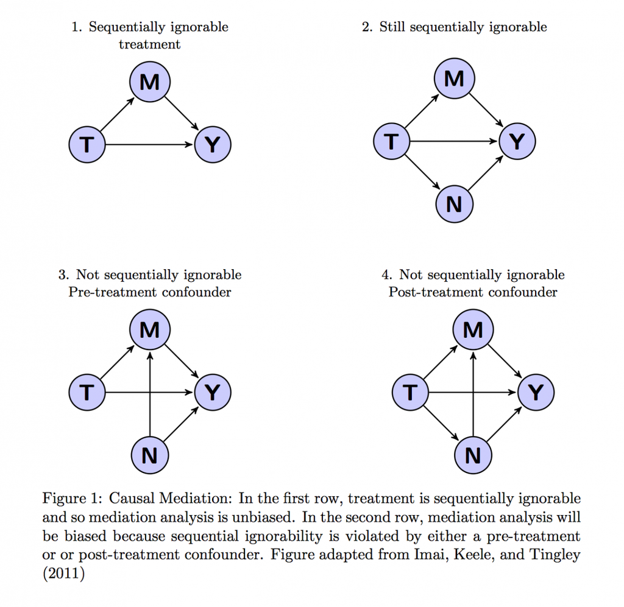

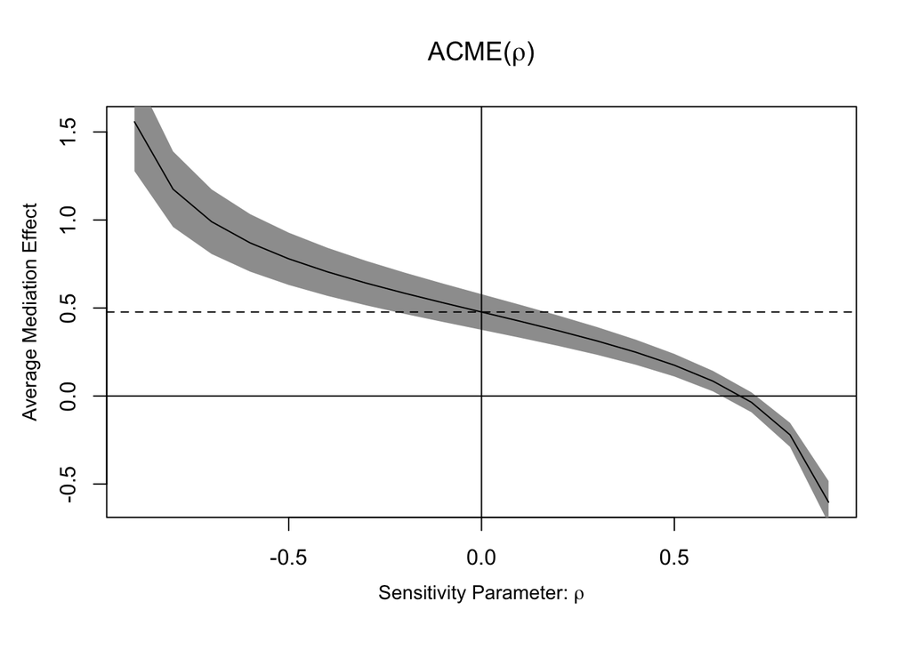

```r
set.seed(1234) # pour la reproductibilité
n = 1000 # taille de la population
Y0 = runif(n) # Résultat potentiel sous la condition de contrôle
D = sample((1:n)%%2) # Traitement: 1 si traité, 0 sinon
X<-rnorm(n) # Covariable
M<-rnorm(n=n,mean=D+rnorm(n)) # Médiateur impacté par le traitement
Y1 = Y0 + 1 + M # Résultat potentiel sous condition de traitement
Y = D*Y1 + (1-D)*Y0 # Résultat dans la population
samp<-data.frame(D,M,Y)
library(mediation)
med.f<-lm(M~D+X,data=samp) # Modèle pour le médiateur
out.f<-lm(Y~M+D+X,data=samp) # Modèle pour le résultat
# Estimer ACME et ADE
library(mediation)
med.out<-
mediate(med.f,out.f,treat="D",mediator="M",robustSE=T,sims=1000)
# Sensibilité de l'ACME à un facteur de confusion pré-traitement non observé
s.out<-medsens(med.out)
plot(s.out) # Tracer les bornes de la sensibilité
```

```r
# Structural equations estimates of ACME ADE
# f1<-formula(Y~D+X)
# f2<-formula(M~D+X)
# f3<-formula(Y~D+M+X)
#
# med.sys<-systemfit(list(f1,f2,f3),data=samp)
# ACME<-coef(med.sys)["eq1_D"]-coef(med.sys)["eq3_D"]
# ADE<-coef(med.sys)["eq3_D"]
```

# 9 Effet du traitement Log-Odds

L’effet moyen du traitement semble un peu difficile à interpréter lorsque les résultats ne sont pas continus. Par exemple, un résultat binaire très courant dans l’étude des élections est codé comme 1 lorsque les sujets ont voté et 0 lorsqu’ils ne l’ont pas fait. L’effet moyen peut être de 0,2, mais qu’est-ce que cela signifie vraiment de dire qu’un traitement a augmenté mon vote de 0,2 ? L’estimation des effets causaux des résultats dichotomiques nécessite des précautions supplémentaires, en particulier lors de l’inclusion de covariables. Une quantité commune d’intérêt causal pour les résultats dichotomiques est l’effet du traitement sur les log-odds de succès, défini pour l’échantillon expérimental comme :

$$\Delta = log\frac{E(Y_i(1))}{1-E(Y_i(1))} - log\frac{E(Y_i(0))}{1-E(Y_i(0))}$$

Freedman (2008b) montre que l’ajustement de covariables dans une régression logistique dans les expériences randomisées produit des estimations biaisées de cet effet causal. L’intuition de base de l’argument de Freedman vient du fait que prendre le log des moyennes n’est pas la même chose que prendre la moyenne des logs et donc le coefficient de traitement estimé à partir d’une régression logistique conditionnée aux covariables ne fournira pas un estimateur cohérent des log-odds de succès. Au lieu de cela, Freedman recommande de prendre les probabilités prédites de variation du statut de traitement des sujets, mais de maintenir leurs profils de covariables observés pour produire un estimateur cohérent des log-odds.

La procédure de base est décrite dans le code ci-dessous. Les coefficients de la régression logistique contrôlant la covariable X ont tendance à surestimer l’effet du traitement sur les log odds, tandis que les estimations ajustées à partir des probabilités prédites produisent des résultats cohérents.

```r
set.seed(1234) # pour la reproductibilité
n = 1000 # taille de la population
U = runif(n)
X = runif(n) # Covariable observée
Y0 = ifelse(U>.5,1,0) # Résultats potentiels
Y1 = ifelse(U+X>.75,1,0)
D = rbinom(n,1,.75) # Assignation aléatoire des 3/4 au traitement
Y = D*Y1+Y0*(1-D)
samp = data.frame(X,D,Y)
aT<-with(samp, mean(Y[D==1]))
aC<-with(samp, mean(Y[D==0]))
# log odds sans conditions
log.odds<-log(aT/(1-aT))-log(aC/(1-aC))
# La régression logistique conditionnée sur X surestime les log odds
fit<-glm(Y~D+X,data=samp,binomial("logit"))
log.odds.logit<-
  coef(glm(Y~D+X,data=samp,binomial("logit")))[2]
# Dataframes utilisant les covariables initiales pour les probabilités prédites
D1<-data.frame(D=1,samp[,c("X")])
D0<-data.frame(D=0,samp[,c("X")])
# Les log-odds ajustés produisent un estimateur consistent des log-cotes
aT.adj<-predict(fit,newdata=D1,type="response")
aC.adj<-predict(fit,newdata=D0,type="response")
log.odds.adj<-log(mean(aT.adj)/(1-mean(aT.adj)))-
  log(mean(aC.adj)/(1-mean(aC.adj)))
```

# 10 Effet attribuable

Nous concluons par une brève discussion sur une autre quantité d’intérêt causal qui peut être particulièrement utile avec des résultats binaires : l’effet attribuable (Rosenbaum 2010). Considérons un cas simple avec un résultat dichotomique et un traitement. Soit $A$ le nombre de résultats attribuables au traitement, c’est-à-dire le nombre de cas pour lesquels $Y_i$ était égal à 1 parmi les sujets traités ; ce qui ne se serait pas produit si ces unités avaient été assignées au contrôle. Pour une plage de $A$, nous ajustons le tableau de contingence observée des résultats parmi les traités et comparons cette distribution résultante à une distribution nulle connue (la distribution des résultats que nous aurions observée si le traitement n’avait eu aucun effet). La plage résultante de $A$ pour laquelle notre test continue de rejeter l’hypothèse nulle d’absence d’effet fournit une plage des effets qui sont attribuables à notre traitement.

| Table 1 | $D=1$ | $D=0$ |
| --- | --- | --- |
| $Y=1$ | $\sum Y_iD_i-A$ | $(1-Y_i)(D_i)$ |
| $Y=0$ | $\sum Y_i(1-D_i)+A$ | $\sum (1-Y_i)(1-D_i)$ |

Rosenbaum (2002) étend ce concept à différents types de résultats (tels que les variables continues). Une logique similaire peut également être appliquée pour détecter des réponses inhabituelles mais importantes au traitement (Rosenbaum et Silber 2008).

Hansen et Bowers (2009) utilisent cette approche pour identifier le nombre de votes supplémentaires attribuables à différentes interventions incitant au vote avec une assignation de traitement par grappe et une non-conformité unilatérale. Ils montrent que, dans de grands échantillons, on peut approximer l’intervalle de confiance pour les effets attribuables sans évaluer chaque attribution. Voici un exemple de cette approche où des covariables sont utilisées pour augmenter la précision.

Premièrement, nous définissons un effet attribuable comme $A=∑_iZ_iτ_i$, où $τ_i=Y_i(1)−Y_i(0)$ et $y∈0,1$ selon Rosenbaum (2002). C’est-à-dire que l’effet attribuable est le nombre de réponses “oui” ou “1” parmi les personnes traitées que nous n’aurions pas vues si elles avaient été dans le groupe de contrôle.

Deuxièmement, notez que si nous écrivons l’ensemble $U$ comme échantillon expérimental et que l’ensemble des unités de contrôle est un sous-ensemble de l’ensemble, $C⊆U$, alors nous pouvons écrire $∑_{i∈C}Y_i −Y_i(0)=0$. Cela signifie que nous pouvons représenter $A$ ainsi :

$$A = ∑_{i=1}^NZ_iτ_i=∑_{i=1}^NZ_i(Y_i(1)−Y_i(0))=∑_{i∉C}y_i(1)−∑_{i∉C}y_i(0)$$
$$= ∑_{i∉C}Y_i−∑_{i∉C}Y_i(0)=∑_{i=1}^NY_i−∑_{i=1}^NY_i(0)=t_U−t_C$$

= total observé globalement (fixe et observé) - résultat total sous contrôle (non observé, à estimer)

Troisièmement, cette représentation nous permet de produire un intervalle de confiance basé sur une conception pour A^ en s’appuyant sur la littérature sur l’échantillonnage pour sondage basé sur l’inférence statistique pour les totaux des échantillons, car les résultats totaux observés, tU, sont fixés à travers une randomisation. Nous pouvons utiliser des covariables pour augmenter la précision ici car l’estimateur de régression pour l’enquête nous permet d’estimer le total que nous aurions vu dans le groupe de contrôle : $\hat{t}_c=\sum_{i∈U}\hat{Y}_i+ \sum_{i∈U}(Y_i-\hat{Y}_i)$ avec $\hat{Y}_i=f(X_i,\beta)$ (Lohr 1999). La littérature sur l’échantillonnage pour les sondages montre que, comme $N→∞$, $CI(\hat{t}_c) \approx \hat{t}_c \pm z_{a/2}SE(\hat{t}_c)$. Ainsi, on peut calculer $\widehat{SE}(\hat{t}_c)$ à partir de la théorie de l’échantillonnage standard puis $CI(\hat{A}) \approx t_U-\widehat{CI}(\hat{t }_c)$.

Dans le code ci-dessous, nous fournissons une illustration utilisant des données simulées pour une réponse binaire et un traitement. Pour 85 % du groupe de traitement, $Y=1$ comparativement à 52 % dans le groupe de contrôle. Une différence de cette taille est cohérente avec le fait que notre traitement a causé $Y=1$ pour 92 à 138 sujets, pour lesquels $Y$ aurait autrement été égal à 0 s’ils n’avaient pas reçu le traitement. L’estimateur de régression, qui tire parti de la précision obtenue en incluant des covariables, produit des intervalles de confiance plus serrés (de 98,8 à 135,1) pour les effets attribuables.

```r
set.seed(1234) # pour la reproductibilité
n = 1000 # taille de la population
X1 = rnorm(n) # Covariables
X2 = rnorm(n)
p = pnorm(-0.5 + 0.75*X2) # Probabilité inégale de traitement
D = rbinom(n, 1, p)
p0 = pnorm(rnorm(n)) # Résultats potentiels pour la réponse binaire
p1 = pnorm(X1 + X2+1)
Y0 = rbinom(n, 1, p0)
Y1 = rbinom(n, 1, p1)
Y = D*Y1 + (1-D)*Y0 # Résultat observé
samp = data.frame(D,Y,X1,X2)
attribute<-function(treat,out,A,data){
  # Contingence de l'état du traitement et des résultats
  attr.tab<-with(data,table(treat,out))
  # Matrice des p-valeurs pour les effets attribuables, A
  attr.ps<-matrix(NA,nc=2,nr=A,dimnames=list(NULL,c("A","p")))
  for(i in 1:A){
    attr.ps[i,]<-
      c(i,fisher.test(attr.tab+matrix(c(0,i,0,-i),2,2))$p)
    }
  # Trouver la plage d'effets
  get.bounds<-function(){
    diffs<-ifelse(.05-attr.ps[,"p"]>0,.05-
                    attr.ps[,"p"],99)
    index<-(diffs %in%
              c(min(diffs),min(diffs[diffs>min(diffs)])))
    index
    }
  # Retourner la plage d'effets
  return (attr.ps[get.bounds(),])
  }
with(samp,table(D,Y))
```

```
##    Y
## D     0   1
##   0 318 339
##   1  51 292
```

```r
with(samp,apply(table(D,Y),1,prop.table))
```

```
##    D
## Y           0        1
##   0 0.4840183 0.148688
##   1 0.5159817 0.851312
```

```r
attribute(treat = D, out= Y, A=200,data=samp)
```

```
##        A          p
## [1,]  92 0.04519869
## [2,] 138 0.04587804
```

```r
# Estimateur de régression
fit1<-lm(Y~X1+X2,data=samp,subset=D==0)
hatYcU<-predict(fit1,newdata=samp)
ec<-Y[D==0]-hatYcU[D==0] # idem aux residuals(fit1)
hatTotYc<-sum(hatYcU)+sum(ec)
N<-length(Y)
nctrls<-sum(1-D)
thefpc<- (1 - (nctrls/N))
varhattC<-N*thefpc*var(Y[D==0])
alpha<-c(.05, 1/3)
alpha<-sort(c(alpha/2, 1-alpha/2))
ciTotYc<-hatTotYc+sqrt(varhattC)*qnorm(alpha)
ciAE<-sort(sum(Y) - ciTotYc )
names(ciAE)<-c("< 95%","< 66%","> 66%","> 95%")
print(ciAE)
```

```
##     < 95%     < 66%     > 66%     > 95%
##  98.78637 107.97975 125.90114 135.09451
```

# Références

Aronow, Peter M et Joel A Middleton. 2013. “A Class of Unbiased Estimators of the Average Treatment Effect in Randomized Experiments.” Journal of Causal Inference 1 (1): 135–54.

Aronow, Peter M et Cyrus Samii. 2014. “Does Regression Produce Representative Estimates of Causal Effects?” In EPSA 2013 Annual General Conference Paper. Vol. 585.

Baron, Reuben M et David A Kenny. 1986. “The Moderator–Mediator Variable Distinction in Social Psychological Research: Conceptual, Strategic, and Statistical Considerations.” Journal of Personality and Social Psychology 51 (6). American Psychological Association: 1173.

Bound, John, David A Jaeger et Regina M Baker. 1995. “Problems with Instrumental Variables Estimation When the Correlation Between the Instruments and the Endogenous Explanatory Variable Is Weak.” Journal of the American Statistical Association 90 (430). Taylor & Francis: 443–50.

Brambor, Thomas, William R. Clark et Matt Golder. 2006. “Understanding Interaction Models: Improving Empirical Analyses.” Political Analysis 14 (1): 63–82.

Bullock, John G, Donald P Green et Shang E Ha. 2010. “Yes, but What’s the Mechanism?(don’t Expect an Easy Answer).” Journal of Personality and Social Psychology 98 (4). American Psychological Association: 550.

Chernozhukov, Victor et Christian Hansen. 2005. “An IV Model of Quantile Treatment Effects.” Econometrica 73 (1). Wiley Online Library: 245–61.

Dunning, Thad. 2010. “Design-Based Inference: Beyond the Pitfalls of Regression Analysis?” Rethinking Social Inquiry: Diverse Tools, Shared Standards. 2nd Ed. Lanham, Md.: Rowman and Littlefield.

Freedman, David A. 2008a. “On Regression Adjustments to Experimental Data.” Advances in Applied Mathematics 40 (2). Elsevier: 180–93. ———. 2008b. “Randomization Does Not Justify Logistic Regression.” Statistical Science 23 (2). Institute of Mathematical Statistics: 237–49.

Frölich, Markus et Blaise Melly. 2010. “Estimation of Quantile Treatment Effects with Stata.” Stata Journal 10 (3): 423.

Gerber, Alan S et Donald P Green. 2012. Field Experiments: Design, Analysis, and Interpretation. WW Norton.

Green, Donald P. 2009. “Regression Adjustments to Experimental Data: Do David Freedman’s Concerns Apply to Political Science?” In 26th Annual Meeting of the Society for Political Methodology, Yale University, July, 23–25.

Hansen, Ben et Jake Bowers. 2009. “Attributing Effects to a Cluster-Randomized Get-Out-the-Vote Campaign.” Journal of the American Statistical Association 104 (487). Taylor & Francis: 873–85.

Hartman, Erin, RD Grieve, R Ramsahai et Jasjeet S Sekhon. forthcoming. “From SATE to PATT: Combining Experimental with Observational Studies.” Journal of the Royal Statistical Society.

Hirano, Keisuke, Guido W Imbens et Geert Ridder. 2003. “Efficient Estimation of Average Treatment Effects Using the Estimated Propensity Score.” Econometrica 71 (4). Wiley Online Library: 1161–89.

Holland, Paul W. 1986. “Statistics and Causal Inference.” Journal of the American Statistical Association 81 (396). Taylor & Francis: 945–60.

Imai, K., L. Keele, D. Tingley et T. Yamamoto. 2011. “Unpacking the Black Box of Causality: Learning About Causal Mechanisms from Experimental and Observational Studies.” American Political Science Review 105 (4). Cambridge Univ Press: 765–89.

Imai, Kosuke et Teppei Yamamoto. 2013. “Identification and Sensitivity Analysis for Multiple Causal Mechanisms: Revisiting Evidence from Framing Experiments.” Political Analysis 21 (2). SPM-PMSAPSA: 141–71.

Imai, Kosuke, Luke Keele et Teppei Yamamoto. 2010. “Identification, Inference and Sensitivity Analysis for Causal Mediation Effects.” Statistical Science. JSTOR, 51–71.

Imai, Kosuke, Gary King et Elizabeth A Stuart. 2008. “Misunderstandings Between Experimentalists and Observationalists About Causal Inference.” Journal of the Royal Statistical Society: series A (Statistics in Society) 171 (2). Wiley Online Library: 481–502.

Imai, Kosuke, Dustin Tingley et Teppei Yamamoto. 2013. “Experimental Designs for Identifying Causal Mechanisms.” Journal of the Royal Statistical Society: Series A (Statistics in Society) 176 (1). Wiley Online Library: 5–51.

Lin, Winston. 2013. “Agnostic Notes on Regression Adjustments to Experimental Data: Reexamining Freedman’s Critique.” The Annals of Applied Statistics 7 (1). Institute of Mathematical Statistics: 295–318.

Lohr, Sharon L. 1999. “Sampling: DesignandAnalysis.” Pacific Grove, CA: Brooks/Cole.

Neyman, Jerzy. 1990 [1923]. “On the Application of Probability Theory to Agricultural Experiments. Essay on Principles. Section 9.” Statistical Science 5 (4). Institute of Mathematical Statistics: 465–72 (Translated by D.M. Dabrowska and T.P. Speed from the original Polish).

Nickerson, D.W. 2008. “Is Voting Contagious? Evidence from Two Field Experiments.” American Political Science Review 102 (1). Cambridge Univ Press: 49.

Rosenbaum, Paul. 2002. “Attributing Effects to Treatment in Matched Observational Studies.” Journal of the American Statistical Association 97 (457). Taylor & Francis: 183–92.

Rosenbaum, Paul R. 2002. Observational Studies. Springer.

Rosenbaum, Paul et Donald B. Rubin. 1983. “The Central Role of the Propensity Score in Observational Studies for Causal Effects.” Biometrika 70 (1). Biometrika Trust: 41–55.

Rosenbaum, Paul et Jeffrey H Silber. 2008. “Aberrant Effects of Treatment.” Journal of the American Statistical Association 103 (481). Taylor & Francis: 240–47.

Rosenbaum, PR. 2010. “Design of Observational Studies.” Springer Series in Statistics. New York [etc.]: Springer. Tingley, Dustin, Teppei Yamamoto, Kentaro Hirose, Luke Keele et Kosuke Imai. 2014. “mediation: R Package for Causal Mediation Analysis.” Journal of Statistical Software 59 (5): 1–38. http://www.jstatsoft.org/v59/i05/.

[^1]: Voir Holland (1986), Angrist et Pischke, Angrist, Joshua et Jörn-Steffen Pischke (2008). Mostly Harmless Econometrics: An Empiricist’s Companion. Princeton University Press.
[^2]: Voir Holland et Angrist & Pischke encore une fois pour une discussion plus formelle de l’indépendance et des hypothèses nécessaires pour estimer les effets causaux.
[^3]: i.e $(E(Y_i(1)|D=1)=E(Y_i(1)|D=0)=E(Y_i(1)))$ et $(E(Y_i(0)|D=1)=E(Y_i(0)|D=0)=E(Y_i(0)))$
[^4]: Les estimations sont souvent écrites avec un chapeau ($\widehat{ATE}$) pour refléter la différence entre l’estimation de notre échantillon particulier et le paramètre, cible de notre estimation qui n’est pas observée. Sauf indication contraire, dans ce guide, nous nous concentrons sur la génération d’estimations d’échantillons et omettons par la suite cette notation explicite par souci de concision. Voir Gerber et Green (2012) pour une introduction concise à cette distinction et Imbens et Wooldridge (2007) pour un traitement approfondi de ces concepts.
[^5]: La covariance de $Y_{i}(1),Y_{i}(0)$ est impossible à observer mais l’estimateur “Neyman” de la variance en omettant le terme de covariance fournit une estimation conservatrice (trop grande) de la vraie variance de l’échantillon parce que nous avons tendance à supposer que la covariance est positive. Étant donné que nous sommes généralement soucieux de minimiser le taux d’erreur de type I (rejetant à tort l’hypothèse nulle vraie), nous préférons utiliser des estimations conservatrices de la variance. Voir aussi Dunning (2010) et Gerber & Green (2012) pour la justification de l’estimateur de variance conservateur.
[^6]: Lin (2013)
[^7]: Brambor, Clark et Golder (2006)
[^8]: Angrist, Joshua et Jörn-Steffen Pischke. 2008. Mostly Harmless Econometrics: An Empiricist’s Companion. Princeton university press.
[^9]: Nous supposons généralement la monotonie, ce qui signifie qu’il n’y a pas de non-conformistes, c’est à dire de personnes qui ne prennent le traitement que lorsqu’elles sont assignées au contrôle ($D_{i}=1$ quand $Z_i=0$) et refusent le traitement lorsqu’elles sont assignées au traitement ($D_{i}=0$ quand $Z_{i}=1$).
[^10]: Angrist, Joshua et Jörn-Steffen Pischke. 2008. Mostly Harmless Econometrics: An Empiricist’s Companion. Princeton university press.; Bound, Jaeger, and Baker (1995)
[^11]: Imai, King et Stuart (2008) pour un examen plus détaillé des questions abordées dans cette section.
[^12]: Imbens, Guido et Jeffrey M Wooldridge. 2007. What’s New in Econometrics? NBER.
[^13]: Angrist et Pischke (2008) fournissent une brève introduction des sujets traités plus en détail par Hirano, Imbens et Ridder (2003), Aronow et Middleton (2013), Glynn et Quinn (2010), et Hartman et al. (à paraître)
[^14]: Glynn, Adam N et Kevin M Quinn. 2010. “An Introduction to the Augmented Inverse Propensity Weighted Estimator.” Political Analysis 18 (1):36–56.
[^15]: Hartman et al. (à paraître) pour voir les efforts visant à combiner des données expérimentales et observationnelles pour passer d’un ATE pour un échantillon à un ATT pour une population.
[^16]: Rosenbaum et Rubin (1983)
[^17]: Abadie, Angrist et Imbens (2002)
[^18]: Chernozhukov et Hansen (2005). C’est-à-dire que le traitement peut avoir des effets hétérogènes, mais l’ordre des résultats potentiels est préservé. Voir Angrist, Joshua et Jörn-Steffen Pischke. 2008. Mostly Harmless Econometrics: An Empiricist’s Companion. Princeton university press.
[^19]: Voir Koenker, Roger et Kevin Hallock. 2001. “Quantile Regression: An Introduction.” Journal of Economic Perspectives 15 (4): 43–56. pour un aperçu concis de la régression par quantile
[^20]: Formellement, Imai, Keele et Yamamoto (2010) définissent les conditions nécessaires d’ignorabilité séquentielle comme : ${Y_i(d',m),M_i(d)}⊥D_i|X_i=x, Y_i(d',m)⊥M_i(d)|D_i=d,X_i=x$. C’est-à-dire que, premièrement, étant donné les covariables de pré-traitement, les résultats potentiels de Y et M sont indépendants du traitement D et, deuxièmement, conditionnés aux covariables de pré-traitement et au statut du traitement, les résultats potentiels sont également indépendants du médiateur.
[^21]: Voir par exemple Imai, Keele et Yamamoto (2010), Imai et al. (2011), Imai, Tingley et Yamamoto (2013), ou Imai et Yamamoto (2013). Aussi voir la discussion de Imai, Tingley et Yamamoto (2013) pour différentes perspectives quand aborder une affirmation sur la médiation avec une analyse de sensibilité ou une analyse des bornes de sensibilité.